# Identifying Movements

Background

Using devices such as Jawbone Up, Nike FuelBand, and Fitbit it is now possible to collect a large amount of data about personal activity relatively inexpensively. These type of devices are part of the quantified self movement – a group of enthusiasts who take measurements about themselves regularly to improve their health, to find patterns in their behavior, or because they are tech geeks. One thing that people regularly do is quantify how much of a particular activity they do, but they rarely quantify how well they do it. In this project, your goal will be to use data from accelerometers on the belt, forearm, arm, and dumbell of 6 participants. Six young health participants were asked to perform one set of 10 repetitions of the Unilateral Dumbbell Biceps Curl in five different fashions: exactly according to the specification (Class A), throwing the elbows to the front (Class B), lifting the dumbbell only halfway (Class C), lowering the dumbbell only halfway (Class D) and throwing the hips to the front (Class E). The goal of this project is to predict the manner in which they did the exercise (the “classe” variable). More information is available from the website here: http://groupware.les.inf.puc-rio.br/har (see the section on the Weight Lifting Exercise Dataset).

### Load the Data

```
Training Dimensions [1] 19622   160
```

```
Testing Dimensions [1]  20 160
```

This data set is provided by: http://groupware.les.inf.puc-rio.br/har

## Method for Building the Model

Create validation set from the training data set

```
Training Dimensions [1] 14718   160
```

```
Validation Dimensions [1] 3682  160
```

### Pre-Processing

1. Remove features adding little to no additional information
2. Standardize numerical values
3. Select features Through correlations between each variable, including the dependent variable, we were able to see that interdependence exists within each of the major areas analyzed, forearm, belt, arm, and dumbbell. By using the variable within each group that is most highly correlated with class, we are able to reduce our features to 5 (including the distinct users).
4. Visualize the interactions of our features

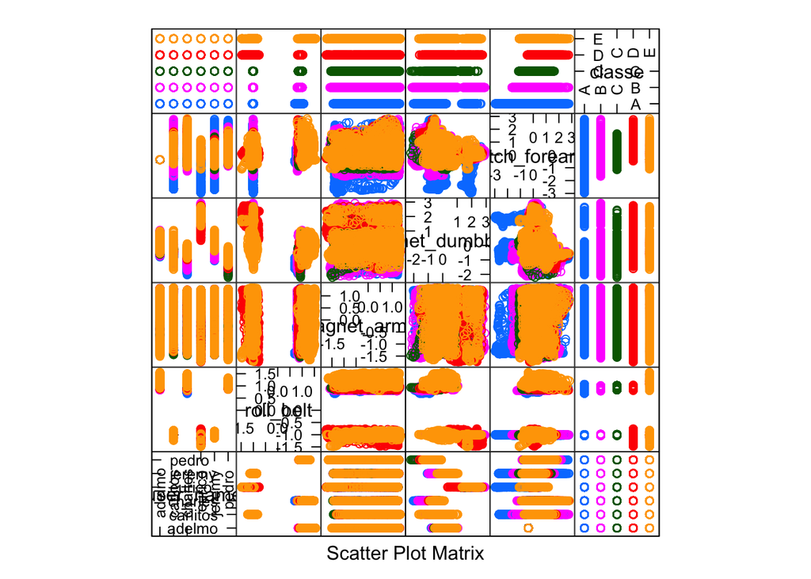

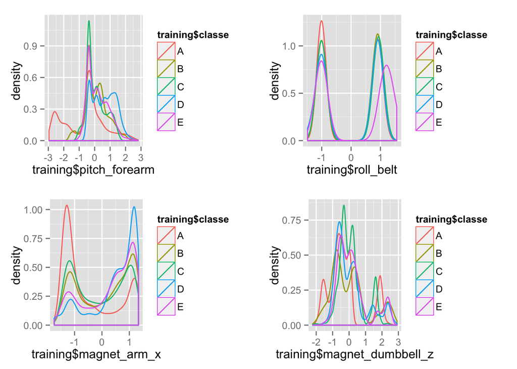

### Train the Data

1. First, we build the model from our training data set. Based on the dependent variable and the features, it appears a random forest will give good results.

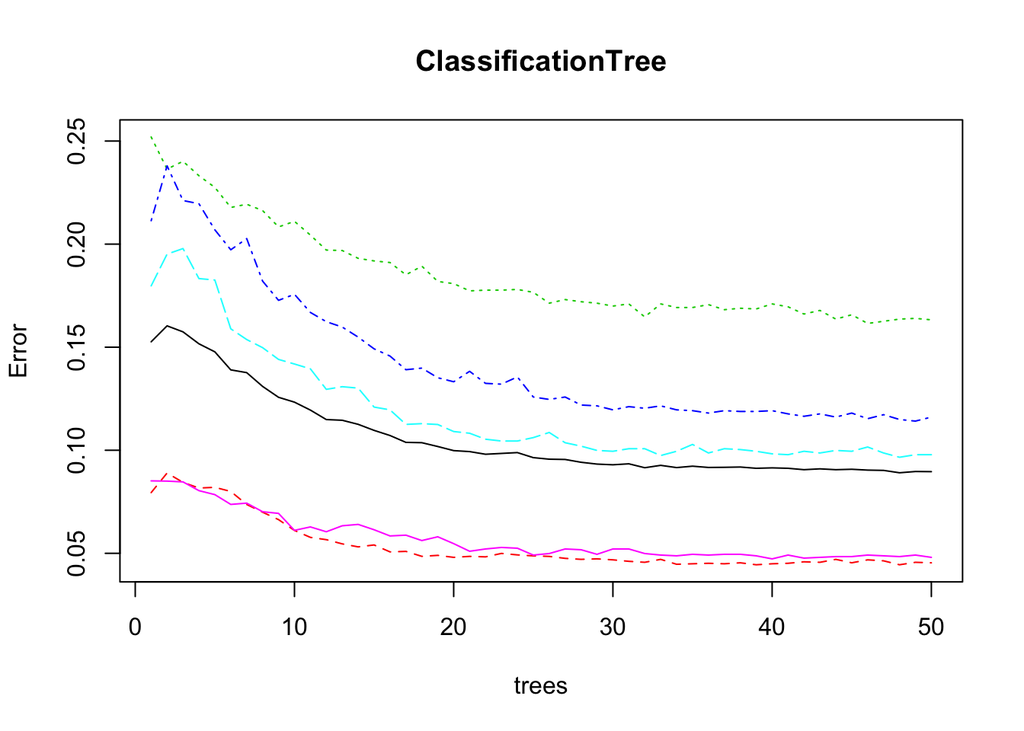

2. Next, we look at the model’s performance through a confusion matrix.

```
Confusion Matrix and Statistics

          Reference
Prediction    A    B    C    D    E
         A 4184    5    6    3    0
         B    0 2823   18    3    2
         C    1    5 2514    3    0
         D    0   15   29 2403    1
         E    0    0    0    0 2703

Overall Statistics

               Accuracy : 0.9938
                 95% CI : (0.9924, 0.995)
    No Information Rate : 0.2843
    P-Value [Acc > NIR] : < 2.2e-16

                  Kappa : 0.9922
 Mcnemar's Test P-Value : NA

Statistics by Class:

                     Class: A Class: B Class: C Class: D Class: E
Sensitivity            0.9998   0.9912   0.9794   0.9963   0.9989
Specificity            0.9987   0.9981   0.9993   0.9963   1.0000
Pos Pred Value         0.9967   0.9919   0.9964   0.9816   1.0000
Neg Pred Value         0.9999   0.9979   0.9957   0.9993   0.9998
Prevalence             0.2843   0.1935   0.1744   0.1639   0.1839
Detection Rate         0.2843   0.1918   0.1708   0.1633   0.1837
Detection Prevalence   0.2852   0.1934   0.1714   0.1663   0.1837
Balanced Accuracy      0.9992   0.9946   0.9893   0.9963   0.9994
```

3. We would estimate our Out-of-Sample Error to be higher than our in-sample error seen above.  
   For an estimate of our out of sample error, we will predict the classes on our validation data set, which we have not used in our exploration or in pre-processing. The resulting confusion matrix and measures of error from our validation data will be our source for our expected out of sample error.

```
Confusion Matrix and Statistics

          Reference
Prediction    A    B    C    D    E
         A 1043    1    2    0    0
         B    0  694    6    0    0
         C    1    1  629    1    0
         D    0    8   12  587    1
         E    0    0    0    0  696

Overall Statistics

               Accuracy : 0.991
                 95% CI : (0.9874, 0.9938)
    No Information Rate : 0.2835
    P-Value [Acc > NIR] : < 2.2e-16

                  Kappa : 0.9887
 Mcnemar's Test P-Value : NA

Statistics by Class:

                     Class: A Class: B Class: C Class: D Class: E
Sensitivity            0.9990   0.9858   0.9692   0.9983   0.9986
Specificity            0.9989   0.9980   0.9990   0.9932   1.0000
Pos Pred Value         0.9971   0.9914   0.9953   0.9655   1.0000
Neg Pred Value         0.9996   0.9966   0.9934   0.9997   0.9997
Prevalence             0.2835   0.1912   0.1763   0.1597   0.1893
Detection Rate         0.2833   0.1885   0.1708   0.1594   0.1890
Detection Prevalence   0.2841   0.1901   0.1716   0.1651   0.1890
Balanced Accuracy      0.9990   0.9919   0.9841   0.9958   0.9993
```

### Predict on Test Cases

```r
test.nonzero <- nonzero[1:127];
    testing <- select(testing,one_of(c(test.nonzero,"problem_id")))
  testing <- testing[-nas]
  testing.preProc <- predict(preObj,testing[,2:54])
    testing <- cbind(testing[1],testing.preProc,testing[55])
  testvars <- c(myvars[1:5],"problem_id")
    testing <- select(testing,one_of(testvars))
  pred.test <- predict(modFit,testing)
  table(pred.test)
```

```
## pred.test
## A B C D E
## 7 8 1 1 3
```